[figure not shown]

# Don't Surprise Me

#### *By Max Humber*

There's a really great scene in SE01E09 of *House of Cards* where Kevin Spacey is whipping votes. In order to get two wry congressmen to vote the way he wants, his character, Frank Underwood, drops this bomb:

> "Vote your district, vote your conscience, don’t surprise me”

I love that. So much. It's a great sound bite and it gets you thinking... How *real* is that quote? How often do elected officials vote their "district" or their "conscience"? How often do they "break rank" and vote against their party? How often would they "surprise" this guy...

[figure not shown]

Well. I found out! For the *41-2 Session of Parliament* in Canada, at least...

## Methodology

1. Pull every single vote for the 41-2 session available at: [openparliament.ca/votes](https://api.openparliament.ca/votes/)
2. Filter for votes on bills with "disagreement"
3. Pull every single individual vote on the bills with "disagreement" available at: [openparliament.ca/votes/ballot](https://api.openparliament.ca/votes/ballots/)
4. Grab party membership for every MP available at: openparliament.ca/
5. Join the three tables
6. Calculate party unity, measured by: **`1 - (votes against party/total votes)`**
7. Go HAM on `ggplot2`

## Results

```r
library(ggplot2)
library(dplyr)
# inline ggplot2
options(jupyter.plot_mimetypes = 'image/png')
```

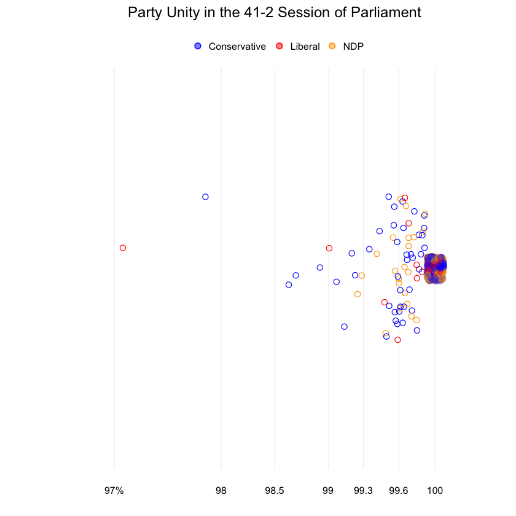

```r
mps <- read.csv("mps.csv")
set.seed(1)

ggplot(data = mps, aes(x = unity, y = 0, color = party)) +
    geom_jitter(data = subset(mps, disagreements > 0),
        shape = 1,
        alpha = 1,
        height = 1.50,
        width = 0.0035,
        size = 2.25) +
    geom_jitter(data = subset(mps, disagreements == 0),
        shape = 16,
        alpha = 0.50,
        width = 0.002,
        height = 0.25,
        size = 3) +
    scale_color_manual(values = c("Blue", "Red", "Orange", "Black")) +
    scale_y_continuous(
        limits = c(-1.5, 1.5),
        breaks = c(-1.5, 0, 1.5),
        labels = c("","","")) +
    scale_x_continuous(
        limits = c(0.965, 1.005),
        breaks = c(0.970, 0.980, 0.985, 0.990, 0.9933, 0.9966, 1),
        labels = c("97%", "98", "98.5", "99", "99.3", "99.6", "100")) +
    ylab("") +  xlab("") + ggtitle("Party Unity in the 41-2 Session of Parliament") +
    theme_minimal() +
    theme(legend.position = "top", legend.title = element_blank(),
        panel.grid.minor.x = element_blank(),
        panel.grid.minor.y = element_blank(),
        panel.grid.major.y = element_blank())
```

## Discussion

There's a lot going on in that graph, so let's unpack it:

The 41-2 Session of Parliament began on October 16th, 2013 and ended on August 2nd, 2015. You'll remember that Stephen Harper was the Prime Minister and the Conservatives controlled the House of Commons with 162 seats (out of a total 308).

There were 467 votes, or bills that session. No Member of Parliament voted on every single bill. And the Liberals and NPD voted with each other and against the Conservatives about ~75% of the time.

You'll notice that x-axis in the graph is scaled from 97% to 100%. Not 0% to 100%. That's not a mistake. The most extreme case of "breaking rank", or rather, lowest *party unity* score for a single Member of Parliament was 97%. This "black sheep" Liberal MP, Eve Adams of Eglinton-Lawrence voted against the Liberals only 14 times **out of a possible 467 votes**. Michael Chong, a conservative MP voted against his party 10 times. (Full list below)

All told, 73 MPs broke rank at least once. The rest of the 271 MPs—that big cluster at 100%—never broke rank. That's 271 MPs that would have never surprised Kevin Spacey. 271 MPs who voted exactly the way their party and party whips told them how to vote.

## Opinion

What's a Canadian MP's job? I'll defer to [this](http://www.theglobeandmail.com/opinion/whats-a-canadian-mps-job-they-dunno/article1317993/) *Globe & Mail* article:

> "The first purpose is to serve one's constituents," said one MP when asked to reflect on his role.

> "People elect you to be in Parliament. They don't elect you to schmooze in the constituency," said another, adding that he feared constituency work had become "a kind of substitute for real input and activity."

> In describing the role of an MP, our interviewees variously emphasized party loyalty, national imperatives, personal priorities and constituency responsibilities. Oddly, only a few MPs mentioned holding government to account for the expenditures of tax dollars, a role political scientists identify as among Parliament's most critical functions.

MPs are meant to represent the interests of their constitiuents in Parliament. Their (main part of their) job is literally to vote on behalf of their district—and conscience—in the House of Parliament. I have a really hard time believing that the 271 MPs who voted with their party 100% of the time had their district's best interest in mind...

MPs are paid $167,400.00 [[Source]](http://www.lop.parl.gc.ca/ParlInfo/lists/Salaries.aspx?Menu=HOC-Politic&Section=03d93c58-f843-49b3-9653-84275c23f3fb). That's an incredible amount of money. And it's incredible amount of money for doing exactly as your told.

One last thing. I just want to point out a funny thing about Ms."Black Sheep" Eve Adams. This past election cycle she was primaried out of her district...

## The Black Sheep List

```r
blacksheep <- mps %>% filter(unity < 1) %>% arrange(unity)
print(blacksheep)
```

```
                      name        party disagreements     unity
1                Eve Adams      Liberal            14 0.9700214
2            Michael Chong Conservative            10 0.9785867
3            Bradley Trost Conservative             6 0.9871520
4           Peter Goldring Conservative             6 0.9871520
5        Stephen Woodworth Conservative             5 0.9892934
6          Gordon O'Connor Conservative             4 0.9914347
7              Mark Warawa Conservative             4 0.9914347
8          Mauril Balanger      Liberal             4 0.9914347
9           Chris Charlton          NDP             3 0.9935760
10            Gerald Keddy Conservative             3 0.9935760
11           James Rajotte Conservative             3 0.9935760
12         John Williamson Conservative             3 0.9935760
13           Wayne Marston          NDP             3 0.9935760
14             Bryan Hayes Conservative             2 0.9957173
```

[output cut: 59 more lines]